# Assignment 02

Jinghua Mu u7457359

2022-10-31

[Github repository location](https://github.com/henflower/Assignment02_meta)

## Part I: Data Processing and Analysis

### 1. Read the study raw data and clean

```r
# install packages
library(pacman)
p_load(tidyverse, flextable, metafor, janitor, ggpmisc, patchwork)
# Install the orchaRd package
## devtools::install_github("daniel1noble/orchaRd", force = TRUE)
library(orchaRd)
```

```r
#read the data of Ckark's research and conceal the index column
current_res <- read_csv("OA_activitydat_20190302_BIOL3207.csv",name_repair = "unique",show_col_types = FALSE) %>%
                     select(-1)
#show context
head(current_res,3)
```

```
## # A tibble: 3 × 8
##   loc       species treatment animal_id    sl size  activity comment
##   <chr>     <chr>   <chr>         <dbl> <dbl> <chr>    <dbl> <chr>
## 1 LIRS 2014 ambon   CO2              64  57.0 big       8.15 27min means of sml…
## 2 LIRS 2014 ambon   CO2              65  38.2 big      10.5  27min means of sml…
## 3 LIRS 2014 ambon   CO2              67  39.3 big       6.51 27min means of sml…
```

```r
# Change some variables to factor to check that the content is correct
current_res <- current_res %>% mutate(loc = as.factor(loc),species = as.factor(species),
                                         size = as.factor(size),treatment = as.factor(treatment))
summary(current_res)
```

```
##         loc           species      treatment     animal_id            sl
##  AIMS 2015: 66   acantho  :196   CO2    :283   Min.   :   1.0   Min.   : 7.50
##  LIRS 2014:195   ambon    : 44   control:306   1st Qu.: 125.0   1st Qu.:11.50
##  LIRS 2016:328   chromis  : 34                 Median : 227.0   Median :24.00
##                  humbug   :142                 Mean   : 281.7   Mean   :26.16
##                  lemon    : 51                 3rd Qu.: 320.0   3rd Qu.:35.25
##                  whitedams:122                 Max.   :9696.0   Max.   :92.53
##                                                NA's   :32
##     size        activity        comment
##  big  :394   Min.   : 1.025   Length:589
##  small:195   1st Qu.:18.622   Class :character
##              Median :27.720   Mode  :character
##              Mean   :28.143
##              3rd Qu.:37.476
##              Max.   :57.573
##              NA's   :7
```

```r
#Check the distribution of NA in the dataset
current_res %>% summarise(across(everything(), ~sum(is.na(.))))
```

```
## # A tibble: 1 × 8
##     loc species treatment animal_id    sl  size activity comment
##   <int>   <int>     <int>     <int> <int> <int>    <int>   <int>
## 1     0       0         0        32     0     0        7       0
```

No spelling errors and particularly unusual values were found, but some values were missing. Because our data is species dependent only, the lack of labels `animal ID` does not affect the availability of the data. So we only removed samples that were missing activities.

```r
#Check whether the number of NA values affects data availability
table(current_res[!complete.cases(current_res$activity),] %>% select(species,loc))
```

```
##            loc
## species     AIMS 2015 LIRS 2014 LIRS 2016
##   acantho           0         2         0
##   ambon             0         1         0
##   chromis           0         0         0
##   humbug            0         2         0
##   lemon             0         2         0
##   whitedams         0         0         0
```

```r
#Remove missing values
current_res <- current_res[complete.cases(current_res$activity),]
```

### 2. Generate statistics and merge files

```r
# the path of metadata file to append new infomation
append_path = "ocean_meta_data.csv"
existing_res <- read_csv(append_path,show_col_types = FALSE)
# Get the amount of information we need
glimpse(existing_res)
```

```
## Rows: 824
## Columns: 22
## $ Study                <chr> "a1", "a1", "a1", "a1", "a1", "a1", "a1", "a2", "…
## $ Authors              <chr> "Munday et al", "Munday et al", "Munday et al", "…
## $ `Year (online)`      <dbl> 2009, 2009, 2009, 2009, 2009, 2009, 2009, 2009, 2…
## $ `Year (print)`       <dbl> 2009, 2009, 2009, 2009, 2009, 2009, 2009, 2010, 2…
## $ Title                <chr> "Ocean acidification impairs olfactory discrimina…
## $ Journal              <chr> "PNAS", "PNAS", "PNAS", "PNAS", "PNAS", "PNAS", "…
## $ `Pub year IF`        <chr> "9.432", "9.432", "9.432", "9.432", "9.432", "9.4…
## $ `2017 IF`            <chr> "9.504", "9.504", "9.504", "9.504", "9.504", "9.5…
## $ `Average n`          <dbl> 27, 27, 27, 27, 27, 27, 27, 15, 15, 15, 15, 15, 1…
## $ `Effect type`        <chr> "Strong", "Strong", "Strong", "Strong", "Strong",…
## $ Species              <chr> "Amphiprion percula", "Amphiprion percula", "Amph…
## $ `Climate (FishBase)` <chr> "Trop", "Trop", "Trop", "Trop", "Trop", "Trop", "…
## $ `Env cue/stimulus?`  <chr> "Yes", "Yes", "Yes", "Yes", "Yes", "Yes", "Yes", …
## $ `Cue/stimulus type`  <chr> "Habitat", "Habitat", "Habitat", "Habitat", "Kin"…
## $ `Behavioural metric` <chr> "% time in Xanthostemon cue", "% time in Melaleuc…
## $ `Life stage`         <chr> "Larvae", "Larvae", "Larvae", "Larvae", "Larvae",…
## $ ctrl.n               <dbl> 26, 20, 20, 10, 30, 30, 30, 45, 45, 45, 45, 45, 4…
## $ ctrl.mean            <dbl> 94.1290, 0.7830, 46.3800, 98.8260, 0.9120, 90.876…
## $ ctrl.sd              <dbl> 2.9931, 3.5017, 14.0023, 1.8563, 2.9960, 3.9984, …
## $ oa.n                 <dbl> 46, 46, 46, 16, 20, 20, 20, 45, 45, 45, 45, 45, 4…
## $ oa.mean              <dbl> 72.7890, 83.5620, 71.4290, 88.2580, 99.8180, 99.8…
## $ oa.sd                <dbl> 13.2730, 10.6211, 13.2730, 7.0440, 0.0045, 0.0045…
```

In order to add the data from the *clark et al.* paper to the metadata file, we needed to generate the appropriate statistics $[mean,sd,N]$ and make the variable names consistent with each other. Therefore, we modify the names of treatment groups and change the names of individual variables, and then use `summarise()` and `pivot_longer()` to generate the statistics in the appropriate format. Finally, we read in clark’s metadata and use `cbind()` to merge the experimental data with the metadata, and then use `select()` to align the data and write it to the metadata file.

```r
# Modify our treatment names to match the reference documentation
levels(current_res$treatment)[levels(current_res$treatment)=="control"] <- "ctrl"
levels(current_res$treatment)[levels(current_res$treatment)=="CO2"] <- "oa"
# calculate mean,SD and N of activity across each species and treatment
current_sta <- current_res %>% group_by(treatment,species) %>% summarise(mean = mean(activity),sd = sd(activity),n = n(),.groups = "drop") %>%
       pivot_wider(names_from = treatment,names_glue = "{treatment}.{.value}",values_from = c(mean,n,sd))
```

```r
# the path of supplemental information about clark's research
current_info <- read_csv("clark_paper_data.csv",show_col_types = FALSE)
# using cbind() to extend supplemental information to each experimental group
append_info <- cbind(tibble(current_info),current_sta)
# colnames(append_info)
#Fix problem with the order and partial naming of columns was found
append_info <- append_info %>%rename(Species = species) %>% select(colnames(existing_res))
```

```r
# write_lines("",file = append_path,append = TRUE)
# write_csv(append_info, file = append_path, append = TRUE,col_names = FALSE)
rm(list = ls())
```

### 3. Generate lnRR and sampling variance

In the previous section we found a problem with data reading for metadata, some numeric variables are read in character format, and we want to check the non-numeric content of these variables and correct all the variables into suitable format.

```r
# Use *janitor* to fix column names for easy selection
meta_data <- read_csv("ocean_meta_data.csv",show_col_types = FALSE) %>% janitor::clean_names()
ini_size = nrow(meta_data)
# Some numeric variables are read in chr type, cheack the non-numeric element
unique(meta_data$pub_year_if[is.na(as.numeric(meta_data$pub_year_if))])
```

```
## [1] "-"
```

```r
unique(meta_data$x2017_if[is.na(as.numeric(meta_data$x2017_if))])
```

```
## [1] "-"
```

```r
#Correct "-" to NA by forced type conversion. Correct some variables to factor type
meta_data[meta_data == "-"] <- NA
meta_data$cue_stimulus_type[is.na(meta_data$cue_stimulus_type)] <- "None"
meta_data <- meta_data %>% mutate(pub_year_if = as.numeric(pub_year_if), x2017_if = as.numeric(x2017_if),
                        effect_type = as.factor(effect_type), climate_fish_base = as.factor(climate_fish_base),
                        env_cue_stimulus = as.factor(env_cue_stimulus), cue_stimulus_type = as.factor(cue_stimulus_type),
                        species = as.factor(species))
# Check the dataset again
summary(meta_data)
```

```
##     study             authors           year_online     year_print
##  Length:824         Length:824         Min.   :2009   Min.   :2009
##  Class :character   Class :character   1st Qu.:2012   1st Qu.:2013
##  Mode  :character   Mode  :character   Median :2015   Median :2015
##                                        Mean   :2015   Mean   :2015
##                                        3rd Qu.:2017   3rd Qu.:2018
##                                        Max.   :2020   Max.   :2020
##
##     title             journal           pub_year_if        x2017_if
##  Length:824         Length:824         Min.   : 0.839   Min.   : 0.794
##  Class :character   Class :character   1st Qu.: 2.504   1st Qu.: 2.504
##  Mode  :character   Mode  :character   Median : 3.730   Median : 3.345
##                                        Mean   : 5.909   Mean   : 5.867
##                                        3rd Qu.: 8.044   3rd Qu.: 8.997
##                                        Max.   :69.500   Max.   :41.580
##                                        NA's   :24       NA's   :15
##    average_n      effect_type                     species
##  Min.   :  4.00   No    :236   Pomacentrus amboinensis:114
##  1st Qu.: 12.00   Strong:474   Amphiprion percula     : 80
##  Median : 17.00   Weak  :114   Gasterosteus aculeatus : 48
##  Mean   : 28.69                Citharichthys stigmaeus: 40
##  3rd Qu.: 30.00                Gadus macrocephalus    : 36
##  Max.   :568.00                Pomacentrus wardi      : 35
##                                (Other)                :471
##     climate_fish_base env_cue_stimulus cue_stimulus_type behavioural_metric
##  Boreal      : 36     No :171          Predator:180      Length:824
##  Deep        :  2     Yes:653          None    :175      Class :character
##  Not provided:  7                      Food    :105      Mode  :character
##  Polar       : 26                      Shelter : 58
##  Subtrop     :221                      Habitat : 56
##  Temp        : 86                      Light   : 44
##  Trop        :446                      (Other) :206
##   life_stage            ctrl_n         ctrl_mean            ctrl_sd
##  Length:824         Min.   :  4.00   Min.   :   -69.78   Min.   :    0.000
##  Class :character   1st Qu.: 10.00   1st Qu.:     1.08   1st Qu.:    1.176
##  Mode  :character   Median : 18.00   Median :     9.52   Median :    5.867
##                     Mean   : 29.14   Mean   :   435.63   Mean   :  103.754
##                     3rd Qu.: 30.00   3rd Qu.:    43.11   3rd Qu.:   21.524
##                     Max.   :752.00   Max.   :154936.88   Max.   :25490.446
##
##       oa_n           oa_mean              oa_sd
##  Min.   :  2.00   Min.   :   -59.67   Min.   :    0.00
##  1st Qu.: 11.00   1st Qu.:     1.21   1st Qu.:    1.17
##  Median : 18.00   Median :    12.37   Median :    7.26
##  Mean   : 29.04   Mean   :   435.35   Mean   :  113.65
##  3rd Qu.: 34.00   3rd Qu.:    43.32   3rd Qu.:   22.05
##  Max.   :755.00   Max.   :157061.25   Max.   :36812.37
##
```

The mean values of both groups were found to vary greatly between experiments. We made an attempt to convert them to **Log response ratio (**$lnRR$**)**.

```r
meta_RR <- metafor::escalc(measure = "ROM", data = meta_data,m1i = oa_mean, m2i = ctrl_mean,
      sd1i = oa_sd, sd2i = ctrl_sd,n1i = oa_n, n2i = ctrl_n,var.names = c("lnRR", "VRR"))
```

The reason for getting NA is that $lnRR = ln\frac{\bar{X_1}}{\bar{X_2}}$, which cannot be calculated when the signs of the two response variables do not agree. We believe that the reason for the inconsistency in the sign of the two variables is that: **part of the experiments screened by metadata is to measure the change from particular baseline for each treatment.**

```r
# Most of NA has *change/rate* in behavioural_metric
meta_RR[!complete.cases(meta_RR$lnRR),] %>% select(study,behavioural_metric, ctrl_mean,oa_mean,lnRR)
```

```
##
##     study                                         behavioural_metric ctrl_mean
## 89     a6                           Prop change in response, 850 ppm     0.408
## 91     a6                           Prop change in response, 850 ppm     0.501
## 93     a6                           Prop change in response, 850 ppm     0.426
## 121   a11 Change in feeding strikes, true conditioning, water, Fig 1     3.009
## 127   a11      Change in area use, pseudo-conditioning, water, Fig 1     0.179
## 128   a11   Change in area use, pseudo-conditioning, predator, Fig 1    -0.441
## 129   a11        Change in area use, true conditioning, water, Fig 1    -0.069
## 130   a11     Change in area use, true conditioning, predator, Fig 1    -2.687
## 137   a11    Change in line crosses, experienced tutor, water, Fig 2    -2.250
## 141   a11        Change in area use, experienced tutor, water, Fig 2     0.195
## 142   a11     Change in area use, experienced tutor, predator, Fig 2    -1.995
## 155   a11                           Change in area use, water, Fig 4    -0.076
## 223   a22                     Mean change bite rate, empty bag, Fig2     1.005
```

[output cut: 34 more lines]

We further counted the keyword occurrences of the study in which the NA experiments were found. The results showed that 104 of the 109 experiments had keywords with **change** and **rate**. We believe that such experiments do not show their effect sizes correctly by response ratio ($lnRR = ln\frac{\bar{X_1}-M}{\bar{X_2}-M} \neq \frac{\bar{X_1}}{\bar{X_2}}$).

```r
# get all the study id of NA values
doubtful_study <- unique(meta_RR[!complete.cases(meta_RR$lnRR),]$study)
# number of experiments matched keyword in doubtful study
num_match <- meta_data %>% filter(study %in% doubtful_study) %>%
         filter(grepl("change|Change|rate|Rate",behavioural_metric)) %>% nrow()
# number of experiments of all study including NA value
num_in_study <- meta_data %>% filter(study %in% doubtful_study) %>% nrow()
print(paste("Num of rows matching keywords:",num_match,",Num of experiments:",num_in_study))
```

```
## [1] "Num of rows matching keywords: 104 ,Num of experiments: 109"
```

Therefore, we chose to **label** the experiments in these studies and all other experiments with the keyword **“change”** to detect the effect size bias between these and other experiments. Also, we removed those experiments where $lnRR$ was NA.

```r
# Remove NA and mark  experiment with change or in "doubtful study"
meta_RR <- meta_RR %>%  filter(!is.na(lnRR)) %>%
         mutate(measure_change = (study %in% doubtful_study)|grepl("change|Change",behavioural_metric) )
```

We test whether the obtained $lnRR$ and its variance $V_{lnRR}$ have a appropriate distribution and size.

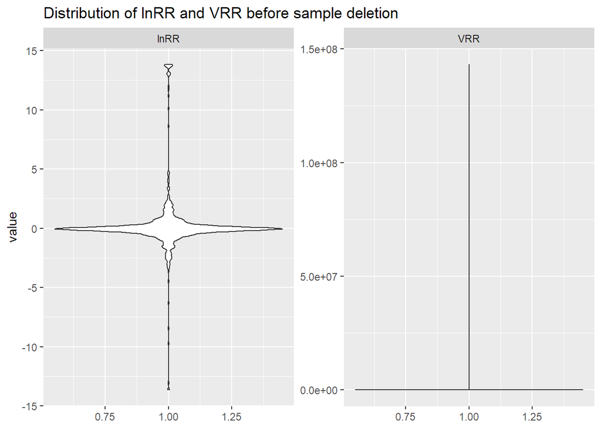

Figure 1: Distribution of lnRR and VRR before sample deletion

```r
# plot distribution of lnRR and VRR
meta_RR %>% select(lnRR, VRR) %>% pivot_longer(cols = lnRR:VRR, names_to = "type", values_to = "value") %>%
      ggplot(aes(x = 1,y = value)) + geom_violin() + facet_wrap(~type, scale = "free") + ggtitle("Distribution of lnRR and VRR before sample deletion") + xlab(NULL)
```

The violin plot Fig 1 shows that the shape of $lnRR$ is consistent with its symmetrical distributed nature, but the values at both ends are large, and the extreme values of the response ratio reach the level of $e^{14}$, which is unimaginable but we cannot deny its plausibility. However, the shape of the $V_{lnRR}$ is extremely anomalous, and there are individual extremely large $V_{lnRR}$. we consider the results of experiments with too large variance relative to the effect values to be unreliable, and we therefore choose to remove these experiments.  
To prevent bias, we used $ (sd(lnRR) > 2|lnRR|) (sd(lnRR) > ln(1.5))$ as a criterion.

```r
# filter unreliable(have unreliable sampling variance) experiments
meta_RR %>% filter( (sqrt(VRR) > 2*abs(lnRR)) & (sqrt(VRR)> log(1.5) )) %>% select(study,ctrl_n:VRR) %>% head(10)
```

```
##
##    study ctrl_n ctrl_mean ctrl_sd oa_n oa_mean   oa_sd    lnRR    VRR
## 1     a3     10    0.0001  0.0001   10  0.0001  0.0001  0.0000 0.2000
## 2     a3     10    0.0001  0.0001   10  0.0001  0.0001  0.0000 0.2000
## 3     a3     10    0.0001  0.0001   10  0.0001  0.0001  0.0000 0.2000
## 4     a3     10    0.0001  0.0001   10  0.0001  0.0001  0.0000 0.2000
## 5     a3     10    0.0001  0.0001   10  0.0001  0.0001  0.0000 0.2000
## 6     a3     10    1.9720  3.6620   10  1.6900  8.4510 -0.1543 2.8454
## 7     a3     10    3.0990  3.9440   10  5.0700 39.4370  0.4923 6.2125
## 8     a5     18   19.2960 31.9810   14 25.0250 32.7171  0.2600 0.2747
## 9     a9     15   43.1140 58.4898   15 39.5210 48.7388 -0.0870 0.2241
## 10    a9     15   43.1140 58.4898   15 36.5270 38.9878 -0.1658 0.1986
```

```r
# delete unreliable(have unreliable sampling variance) experiments
meta_RR <- meta_RR %>% filter((sqrt(VRR) <= 2*abs(lnRR)) | (sqrt(VRR) <= log(1.5) ))
print(paste("Initial number of experiment:",ini_size,",after screen:",nrow(meta_RR)))
```

```
## [1] "Initial number of experiment: 824 ,after screen: 727"
```

```r
# Write the processed file to a csv file
write_csv(meta_RR,"meta_RR.csv")
```

By screening, we removed 97 of the 824 experiments, which reduced the validity of our meta-analysis but was more conducive to obtaining reliable results.

After removing some of the samples, we redraw the distributions of $lnRR$ and $V_{lnRR}$ and show the experiments measuring the degree of change in another color.

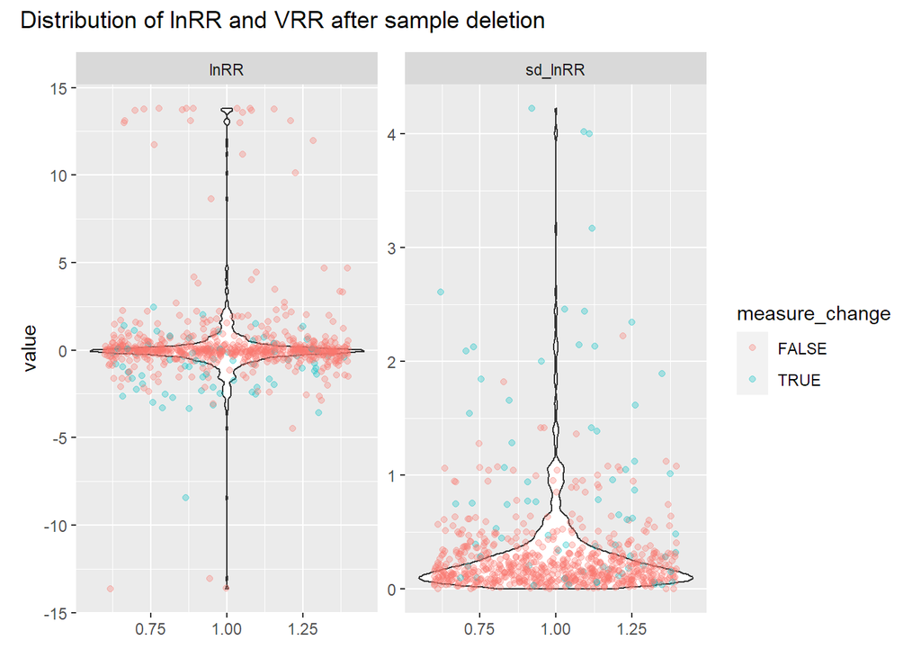

Figure 2: Distribution of lnRR and VRR after sample deletion

```r
meta_RR %>% mutate(sd_lnRR = sqrt(VRR)) %>% select(lnRR, sd_lnRR, measure_change) %>% pivot_longer(cols = c(lnRR,sd_lnRR), names_to = "type", values_to = "value") %>% ggplot(aes(x = 1,y = value)) + geom_violin() +geom_jitter(alpha = 0.3,aes(color = measure_change))+ facet_wrap(~type, scale = "free") + xlab(NULL) + plot_annotation(
  title = "Distribution of lnRR and VRR after sample deletion")
```

As we can also see from the violin plot Fig 2 added measurement method, the experiments that measure the ratio of change generally have large effect values and sampling variance. And even after removing the experiments with low confidence, some of the effect values are still too large and the sampling variance still has some extreme values.

we observe the difference in distribution density between the two experimental data measurement types further through density plots.

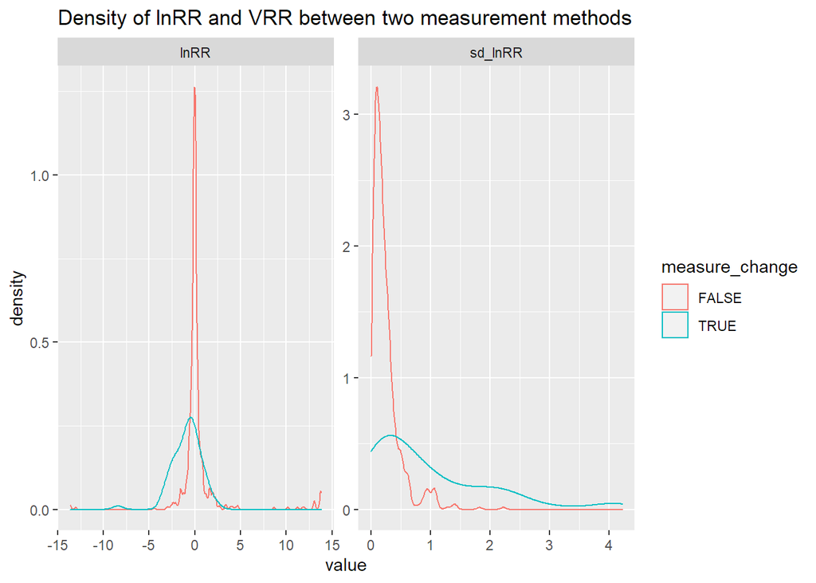

Figure 3: Density of lnRR and VRR between two measurement methods

```r
meta_RR %>% mutate(sd_lnRR = sqrt(VRR)) %>% select(lnRR, sd_lnRR, measure_change) %>% pivot_longer(cols = c(lnRR,sd_lnRR), names_to = "type", values_to = "value") %>%
      ggplot(aes(x = value)) + geom_density(aes(color = measure_change)) + facet_wrap(~type, scale = "free") + ggtitle("Density of lnRR and VRR between two measurement methods")
```

By plotting the density Fig 3, we find that experiments measuring the rate of change do have higher absolute effect values and show greater sampling variance.

## Part II: Meta Analysis of OA Research

### 4. Overall meta-analysis

Before fitting the Multi-level meta-analytic model, we need to know the **composition of the experimental design** of the different studies in order to better design the random effect factors.

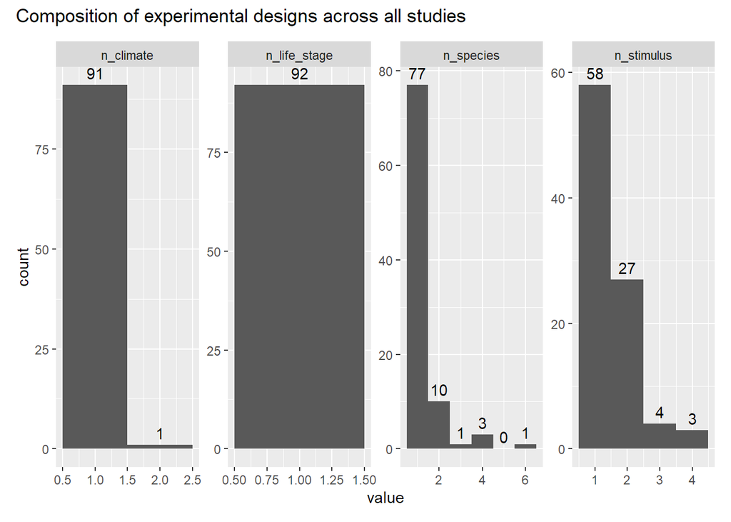

Figure 4: Composition of experimental designs across all studies

```r
# Read processed meta-analysis data
meta_RR <- read_csv("meta_RR.csv", show_col_types = FALSE)
# Fix a UTF-8 encoded label of species
meta_RR$species[grepl("Hippocampus",meta_RR$species)] = "Hippocampus guttulatus"

#draw fig4
meta_RR %>% group_by(study) %>%
    summarise(n_climate = length(unique(climate_fish_base)), n_species = length(unique(species)), n_life_stage = length(unique(life_stage)),n_stimulus= length(unique(cue_stimulus_type))) %>%
    pivot_longer(cols = -1,names_to = "type", values_to = "value") %>%
    ggplot(aes(x = value)) + geom_histogram(binwidth = 1) + geom_text(aes(label=as.character(..count..)),stat="bin",binwidth=1,vjust=-0.5) +
    facet_wrap(~type,scale = "free",nrow = 1) + plot_annotation(
  title = "Composition of experimental designs across all studies")
```

We counted the number of materials and study methods for each study. It can be found in Fig 4 that almost every study studied only one zone (with only one exception) and one fish life stage.Therefore we assume that climate and life stage do not affect the variance composition of study. Instead, the internal variance of each study may be influenced by the method and the number of species it uses.

At the same time, we also counted the life stages involved in each species, the types of stimuli they received, and how many studies were involved.

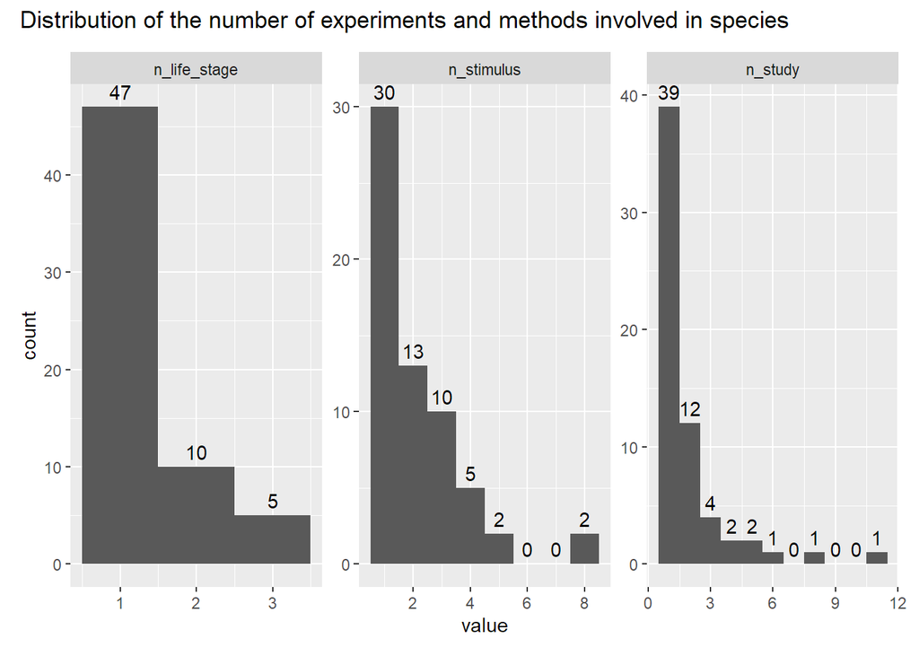

Figure 5: Distribution of the number of experiments and methods involved in species

```r
meta_RR %>% group_by(species) %>%
    summarise(n_study = length(unique(study)), n_life_stage = length(unique(life_stage)),n_stimulus= length(unique(cue_stimulus_type))) %>%
    pivot_longer(cols = -1,names_to = "type", values_to = "value") %>%
    ggplot(aes(x = value)) + geom_histogram(binwidth = 1) + geom_histogram(binwidth = 1) + geom_text(aes(label=as.character(..count..)),stat="bin",binwidth=1,vjust=-0.5) +
    facet_wrap(~type,scale = "free") + plot_annotation(
  title = "Distribution of the number of experiments and methods involved in species")
```

We found in Fig 5 that each species was mostly studied at only one of its growth stages. Most species appeared in only one study, with little overlap of species between studies. And nearly half of the species in all experiments were studied under multiple study instruments (stimulus).

Combining Fig 4 and Fig 5, we found that most of the published studies mostly used only one growth stage of a species as a sample, most of the studies using multiple species involved only one zone, and only one to two study instruments (stimulus) were used in each study. Therefore, we can assume that most of the factors affecting the within-study variance are differences in the stimuli used and the number of studies per study.

In addition, we can make Q-Q plots to test whether the mean distribution of $lnRR$ in each factor conforms to a normal distribution, thereby confirming whether these effects lead to non-random differences. First, we make Q-Q plots for different effect_types to better show the deviation of the overall distribution of $lnRR$ from the normal distribution.

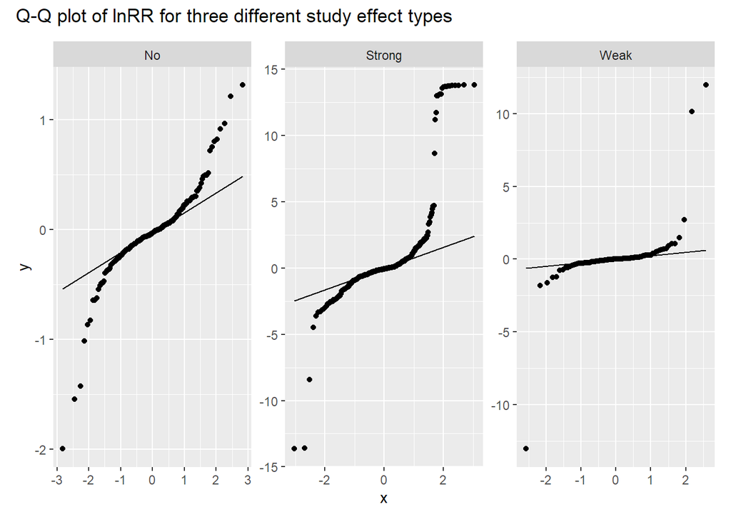

Figure 6: Q-Q plot of lnRR for three different study effect types

```r
meta_RR %>% ggplot(aes(sample = lnRR)) + stat_qq() + stat_qq_line() + facet_wrap(~effect_type,scale = "free") +  plot_annotation(
  title = "Q-Q plot of lnRR for three different study effect types")
```

As seen in Fig 6, each reported response type deviates significantly from the normal distribution and shows strong thick tails, implying the presence of many extreme values of $lnRR$. Also, we can see that the Q-Q plot fits to $lnRR$ are centered at 0, which implies that the general effect values are distributed approximately symmetrically at both ends of 0. This is because each study has different values measured by the study instruments and the effect values have different meanings for the species. At the same time, however, the graph also implies that we can quantify absolute effect sizes by counting the absolute value of $lnRR$.

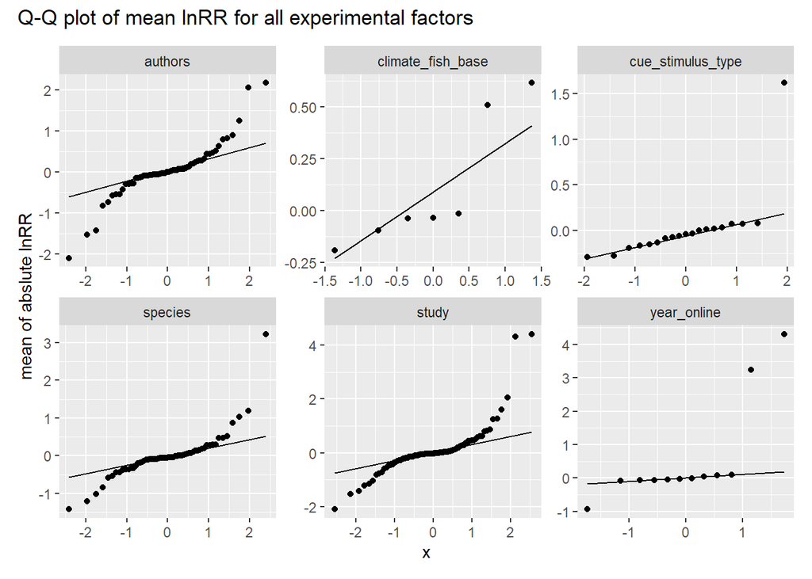

Figure 7: Q-Q plot of mean lnRR for all experimental factors

```r
para_distribution <- function(data,paras){
   plot_data <- tibble()
   for (i in paras){
      c <- ensym(i)
      para_data <- data %>% group_by({{c}}) %>% summarise(mean_lnRR = mean(lnRR)) %>%
          select(mean_lnRR) %>% mutate(parameter = as.character(i))
      plot_data <- rbind(para_data,plot_data)
   }
   plot_data %>% ggplot(aes(sample = mean_lnRR)) + stat_qq() + stat_qq_line() + facet_wrap(~parameter,scale = "free") + ylab("mean of abslute lnRR") +  plot_annotation(
  title = "Q-Q plot of mean lnRR for all experimental factors")
}

para_distribution(meta_RR,c("species","study","climate_fish_base","cue_stimulus_type","year_online","authors"))
```

At the same time, the Q-Q plots for different experimental factors Fig 7 show that, except for the effect size of the stimulus type, which conforms to a normal distribution centered at 0, the results of other experimental factors deviate significantly from the normal distribution.

We therefore consider that the main experiment random effect belongs to the **study**, while the **stimulus type** as different experimental methods in a single **study** leads to different between-group variance, while other variance is contributed by differences in conditions between experiments(contain the use of **species**) and the experiment itself. From this we build a meta-analytic model.(Because the ecological niche in which a species is located may determine the type of stimulus it receives)

```r
meta_RR <- meta_RR %>% group_by(study) %>% mutate(exp_id = 1:n()) %>% ungroup()
```

```r
# Multi-level meta-analytic model
MLMA <- metafor::rma.mv(lnRR ~ 1, V = VRR, method = "REML",
            random = list( ~1|study/cue_stimulus_type/species/exp_id),
            dfs = "contain", test = "t", data = meta_RR)
summary(MLMA)
```

```
##
## Multivariate Meta-Analysis Model (k = 727; method: REML)
##
##     logLik    Deviance         AIC         BIC        AICc
## -1596.2804   3192.5609   3202.5609   3225.4986   3202.6442
##
## Variance Components:
##
##             estim    sqrt  nlvls  fixed                                  factor
## sigma^2.1  0.0000  0.0001     92     no                                   study
## sigma^2.2  1.2771  1.1301    136     no                 study/cue_stimulus_type
## sigma^2.3  0.1005  0.3170    167     no         study/cue_stimulus_type/species
## sigma^2.4  3.4699  1.8628    727     no  study/cue_stimulus_type/species/exp_id
##
## Test for Heterogeneity:
## Q(df = 726) = 736088983.8671, p-val < .0001
##
## Model Results:
##
## estimate      se    tval  df    pval    ci.lb   ci.ub
##   0.1609  0.1347  1.1949  91  0.2352  -0.1066  0.4284
##
## ---
## Signif. codes:  0 '***' 0.001 '**' 0.01 '*' 0.05 '.' 0.1 ' ' 1
```

Because 1. we do not set the independent variable corresponding to $lnRR$ but only measure the mean value  
2. the difference between the extreme values of $lnRR$ is too large  
3. the difference of using species、experimental methods and experimental variable between different experiments is large  
4. No consistent measurements across experiments

Our results are not significant with p-value 0.235. Although our 95% confidence interval contains 0, the results obtained are still somewhat informative, with the average $lnRR$ being 0.161.

```r
p_MLMA <- predict(MLMA, transf = exp)
p_MLMA
```

```
##
##    pred  ci.lb  ci.ub  pi.lb   pi.ub
##  1.1746 0.8989 1.5348 0.0147 93.9248
```

Measures of heterogeneity in effect size estimates across studies $I^2$:

```r
## Calculate I2
library(orchaRd)
i2_vals <- orchaRd::i2_ml(MLMA)
i2 <- tibble(type = firstup(gsub("I2_", "", names(i2_vals))), I2 = round(i2_vals,4))
flextable(i2) %>%
   align(part = "header", align = "center") %>%
   compose(part = "header", j = 1, value = as_paragraph(as_b("Type"))) %>%
   compose(part = "header", j = 2, value = as_paragraph(as_b("I"), as_b(as_sup("2")), as_b("(%)")))
```

Table 1: I^2 of overall meta analysis model

| Type | I2(%) |
| --- | --- |
| Total | 100.0000 |
| Study | 0.0000 |
| Study/cue_stimulus_type | 26.3461 |
| Study/cue_stimulus_type/species | 2.0726 |
| Study/cue_stimulus_type/species/exp_id | 71.5813 |

Surprisingly, the random effect explains 100% of the variance, while the sampling variance is too small to show its proportion because it is relatively too small. This suggests that our data are extremely heterogeneous for the same reasons as above, both due to high variability in experimental design and measurements between experiments.It can be seen that the variance between studies was decomposed to account for approximately 0. While the stimulus type explained 26.3461% of the variance and species explained 2.0726%of the variance.

We also tried the same meta-analysis using the absolute value of $lnRR$, although this would lead to random effects not meeting the assumption of a normal distribution and the t-test would be inaccurate.

```r
# Multi-level meta-analytic model
meta_RR <- meta_RR %>% mutate(abs_lnRR = abs(lnRR))
MLMA2 <- metafor::rma.mv(abs_lnRR ~ 1, V = VRR, method = "REML",
           random = list(~1|study/cue_stimulus_type/species/exp_id),
            dfs = "contain", test = "t", data = meta_RR)
MLMA2
```

```
##
## Multivariate Meta-Analysis Model (k = 727; method: REML)
##
## Variance Components:
##
##             estim    sqrt  nlvls  fixed                                  factor
## sigma^2.1  0.1728  0.4157     92     no                                   study
## sigma^2.2  0.9033  0.9504    136     no                 study/cue_stimulus_type
## sigma^2.3  0.1228  0.3504    167     no         study/cue_stimulus_type/species
## sigma^2.4  3.0226  1.7386    727     no  study/cue_stimulus_type/species/exp_id
##
## Test for Heterogeneity:
## Q(df = 726) = 247092041.1504, p-val < .0001
##
## Model Results:
##
## estimate      se    tval  df    pval   ci.lb   ci.ub
##   0.7098  0.1295  5.4813  91  <.0001  0.4526  0.9670  ***
##
## ---
## Signif. codes:  0 '***' 0.001 '**' 0.01 '*' 0.05 '.' 0.1 ' ' 1
```

Fitting to the absolute value of $lnRR$ yielded a very high estimate mean value of 0.71, with a very small p-value of 0. This shows that the absolute effect size of our study is high. That mean the response ratio between two treatment groups across experiments is 2.034.

Measures of heterogeneity in effect size estimates across studies $I^2$ for absolute $lnRR$:

```r
## Calculate I2
library(orchaRd)
i2_vals <- orchaRd::i2_ml(MLMA2)
i2 <- tibble(type = firstup(gsub("I2_", "", names(i2_vals))), I2 = round(i2_vals,4))
flextable(i2) %>%
   align(part = "header", align = "center") %>%
   compose(part = "header", j = 1, value = as_paragraph(as_b("Type"))) %>%
   compose(part = "header", j = 2, value = as_paragraph(as_b("I"), as_b(as_sup("2")), as_b("(%)")))
```

Table 2: I^2 of overall meta analysis model in abs(lnRR)

| Type | I2(%) |
| --- | --- |
| Total | 100.0000 |
| Study | 4.0943 |
| Study/cue_stimulus_type | 21.3968 |
| Study/cue_stimulus_type/species | 2.9083 |
| Study/cue_stimulus_type/species/exp_id | 71.6005 |

Using absolute values does not explain the variance any better. Because of the large variation between our different experiments, it still leads to 100% heterogeneity, but the variance explained by study comes back to a more reasonable level.

Finally, we make a meta-analysis of the overall forest plot.

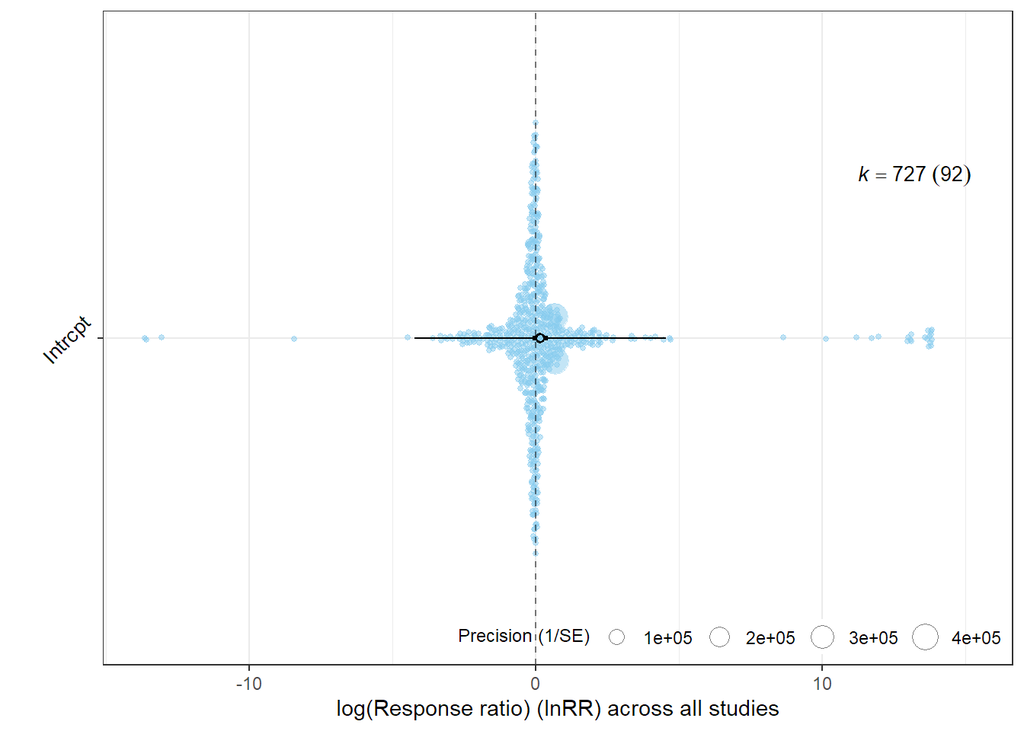

Figure 8: Orchard plot of lnRR across all study

```r
orchaRd::orchard_plot(MLMA, mod = "1", group = "study", data = meta_RR,
    xlab = "log(Response ratio) (lnRR) across all studies", angle = 45)
```

In Fig 8, it can be seen that the results are consistent with MLMA1, the mean value of $lnRR$ is positive, and the 95% confidence interval intersects with 0.

### 5. Analysis of biological and methodological factor

First, whether we fit biological factors can better explain the changes in $lnRR$.  
The effect of ocean acidification may be different in different habitats (climate zones) because of natural differences in CO2 concentration in the ocean due to temperature differences in different habitats.

```r
# Experiments didn't mark habitats were remove
meta_RR_climate <- meta_RR %>% filter(climate_fish_base != "Not provided")
MLMR1 <- metafor::rma.mv(lnRR ~ climate_fish_base-1, V = VRR, method = "REML",
                         random = list(~1|species, ~1|study/exp_id),
                         dfs = "contain", test = "t", data = meta_RR_climate)
MLMR1
```

```
##
## Multivariate Meta-Analysis Model (k = 721; method: REML)
##
## Variance Components:
##
##             estim    sqrt  nlvls  fixed        factor
## sigma^2.1  0.2396  0.4895     61     no       species
## sigma^2.2  0.3281  0.5728     91     no         study
## sigma^2.3  4.1897  2.0469    721     no  study/exp_id
##
## Test for Residual Heterogeneity:
## QE(df = 715) = 10983677.9347, p-val < .0001
##
## Test of Moderators (coefficients 1:6):
## F(df1 = 6, df2 = 55) = 0.4730, p-val = 0.8254
##
## Model Results:
##
##                           estimate      se     tval   df    pval    ci.lb
## climate_fish_baseBoreal    -0.0368  0.8272  -0.0445   55  0.9646  -1.6947
## climate_fish_baseDeep       0.5100  1.6530   0.3085   55  0.7589  -2.8028
## climate_fish_basePolar     -0.1065  0.7131  -0.1494   85  0.8816  -1.5244
## climate_fish_baseSubtrop   -0.1736  0.2440  -0.7116   55  0.4797  -0.6625
## climate_fish_baseTemp      -0.0931  0.3175  -0.2932  715  0.7694  -0.7164
## climate_fish_baseTrop       0.2928  0.2004   1.4609   55  0.1497  -0.1088
##                            ci.ub
## climate_fish_baseBoreal   1.6210
## climate_fish_baseDeep     3.8227
## climate_fish_basePolar    1.3114
## climate_fish_baseSubtrop  0.3153
## climate_fish_baseTemp     0.5302
## climate_fish_baseTrop     0.6944
##
## ---
## Signif. codes:  0 '***' 0.001 '**' 0.01 '*' 0.05 '.' 0.1 ' ' 1
```

Giving the orchard plot for different habitats.

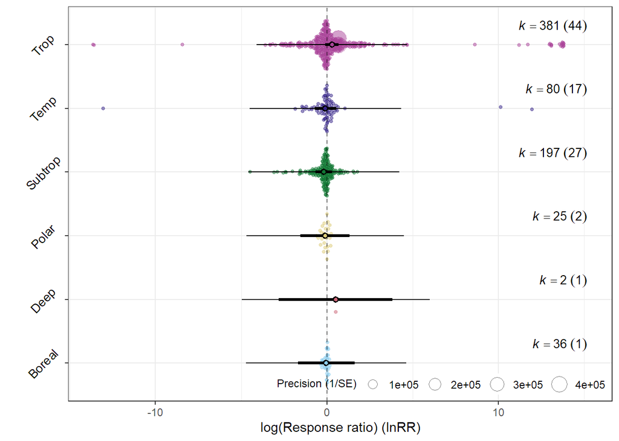

Figure 9: Orchard plot for different habitats

```r
orchaRd::orchard_plot(MLMR1, mod = "climate_fish_base", group = "study", data = meta_RR_climate,
    xlab = "log(Response ratio) (lnRR)", angle = 45)
```

```r
rm(meta_RR_climate)
```

From Fig 9, it can be seen that the mean values of most of the habitats basically fall at zero. While some of the experiments with large sample sizes and some of the experiments with more extreme values cause the mean values to deviate from zero.

At the same time, it is widely believed that ocean acidification may have different effects on different life stages of fish. We therefore fit the mean of $lnRR$ for different life stages of the fish.

```r
# Experiments didn't mark life stage were remove
meta_RR_stage <- meta_RR %>% filter(life_stage != "Not provided")
MLMR2 <- metafor::rma.mv(lnRR ~ life_stage -1, V = VRR, method = "REML",
                         random = list(~1|species, ~1|study/exp_id),
                         dfs = "contain", test = "t", data = meta_RR_stage)
MLMR2
```

```
##
## Multivariate Meta-Analysis Model (k = 701; method: REML)
##
## Variance Components:
##
##             estim    sqrt  nlvls  fixed        factor
## sigma^2.1  0.2581  0.5080     58     no       species
## sigma^2.2  0.3067  0.5538     89     no         study
## sigma^2.3  4.3245  2.0795    701     no  study/exp_id
##
## Test for Residual Heterogeneity:
## QE(df = 698) = 735922427.5080, p-val < .0001
##
## Test of Moderators (coefficients 1:3):
## F(df1 = 3, df2 = 86) = 1.0944, p-val = 0.3560
##
## Model Results:
##
##                     estimate      se     tval  df    pval    ci.lb   ci.ub
## life_stageAdult      -0.1109  0.2696  -0.4114  86  0.6818  -0.6469  0.4251
## life_stageJuvenile   -0.0764  0.2057  -0.3713  86  0.7113  -0.4853  0.3326
## life_stageLarvae      0.3491  0.2125   1.6428  86  0.1041  -0.0733  0.7715
##
## ---
## Signif. codes:  0 '***' 0.001 '**' 0.01 '*' 0.05 '.' 0.1 ' ' 1
```

Giving the orchard plot for different life stages.

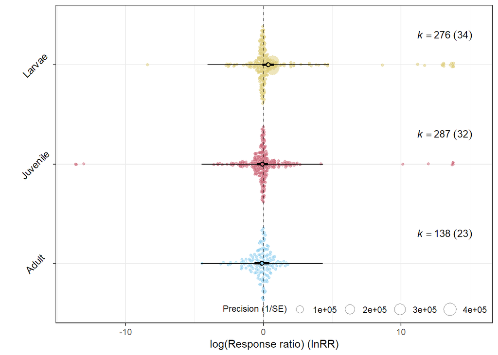

Figure 10: Orchard plot for different life stages

```r
orchaRd::orchard_plot(MLMR2, mod = "life_stage", group = "study", data = meta_RR_stage,
    xlab = "log(Response ratio) (lnRR)", angle = 45)
```

```r
rm(meta_RR_stage)
```

Fig 10 confirms our previous conclusions, and we find several studies with great precision focused on the larvae domain, which seems to be related to the large positive effect values in this domain.

```r
# Experiments didn't mark climate and life stage were remove
meta_RR_cs <- meta_RR %>% filter(life_stage != "Not provided" & climate_fish_base != "Not provided")
MLMR3 <- metafor::rma.mv(abs_lnRR ~ climate_fish_base + life_stage -1, V = VRR, method = "REML",
                         random = list(~1|species, ~1|study/exp_id),
                         dfs = "contain", test = "t", data = meta_RR_cs)
MLMR3
```

```
##
## Multivariate Meta-Analysis Model (k = 701; method: REML)
##
## Variance Components:
##
##             estim    sqrt  nlvls  fixed        factor
## sigma^2.1  0.2025  0.4500     58     no       species
## sigma^2.2  0.4980  0.7057     89     no         study
## sigma^2.3  3.5096  1.8734    701     no  study/exp_id
##
## Test for Residual Heterogeneity:
## QE(df = 693) = 10808984.8951, p-val < .0001
##
## Test of Moderators (coefficients 1:8):
## F(df1 = 8, df2 = 50) = 3.2867, p-val = 0.0043
##
## Model Results:
##
##                           estimate      se     tval  df    pval    ci.lb
## climate_fish_baseBoreal    -0.1158  0.9568  -0.1211  50  0.9041  -2.0377
## climate_fish_baseDeep       0.4700  1.6261   0.2890  50  0.7737  -2.7961
## climate_fish_basePolar      0.1510  0.8149   0.1852  81  0.8535  -1.4705
## climate_fish_baseSubtrop    0.3307  0.3392   0.9752  50  0.3342  -0.3505
## climate_fish_baseTemp       0.4602  0.3940   1.1680  81  0.2463  -0.3238
## climate_fish_baseTrop       0.8040  0.3144   2.5573  50  0.0136   0.1725
## life_stageJuvenile          0.0399  0.3451   0.1156  81  0.9082  -0.6467
## life_stageLarvae            0.2198  0.3424   0.6421  81  0.5226  -0.4614
##                            ci.ub
## climate_fish_baseBoreal   1.8060
## climate_fish_baseDeep     3.7361
## climate_fish_basePolar    1.7724
## climate_fish_baseSubtrop  1.0119
## climate_fish_baseTemp     1.2442
## climate_fish_baseTrop     1.4355  *
## life_stageJuvenile        0.7265
## life_stageLarvae          0.9011
##
## ---
## Signif. codes:  0 '***' 0.001 '**' 0.01 '*' 0.05 '.' 0.1 ' ' 1
```

We use `orchaRd::r2_ml()` to see how well the three models explain variance.

```r
R2 <- as.data.frame(orchaRd::r2_ml(MLMR1))
R2 <- cbind(R2,as.data.frame(orchaRd::r2_ml(MLMR2)))
R2 <- cbind(R2,as.data.frame(orchaRd::r2_ml(MLMR3)))
colnames(R2) <- c("climate","life stage","climate + life stage")
knitr::kable(R2,caption = "Variance explained by different publication bias meta-analysis models")
```

Table 3: Variance explained by different publication bias meta-analysis models

|  | climate | life stage | climate + life stage |
| --- | --- | --- | --- |
| R2_marginal | 0.0098079 | 0.0092687 | 0.0197421 |
| R2_conditional | 0.1279659 | 0.1237180 | 0.1828463 |

As can be seen from the table 3, using two variables at the same time explains the variance between experiments relatively better. However, due to the high variation between experiments, the fixed factor still only explains the variance of 0.02.

Because we believe that using the absolute values of the effect sizes better reflects the magnitude of the differences and the “value” of the study. Therefore, we used the average absolute value of $lnRR$ and the sample size of the study to make a heat map of these two fixed factors. Also, we used a linear fit to see if the study area with stronger effects was more popular.

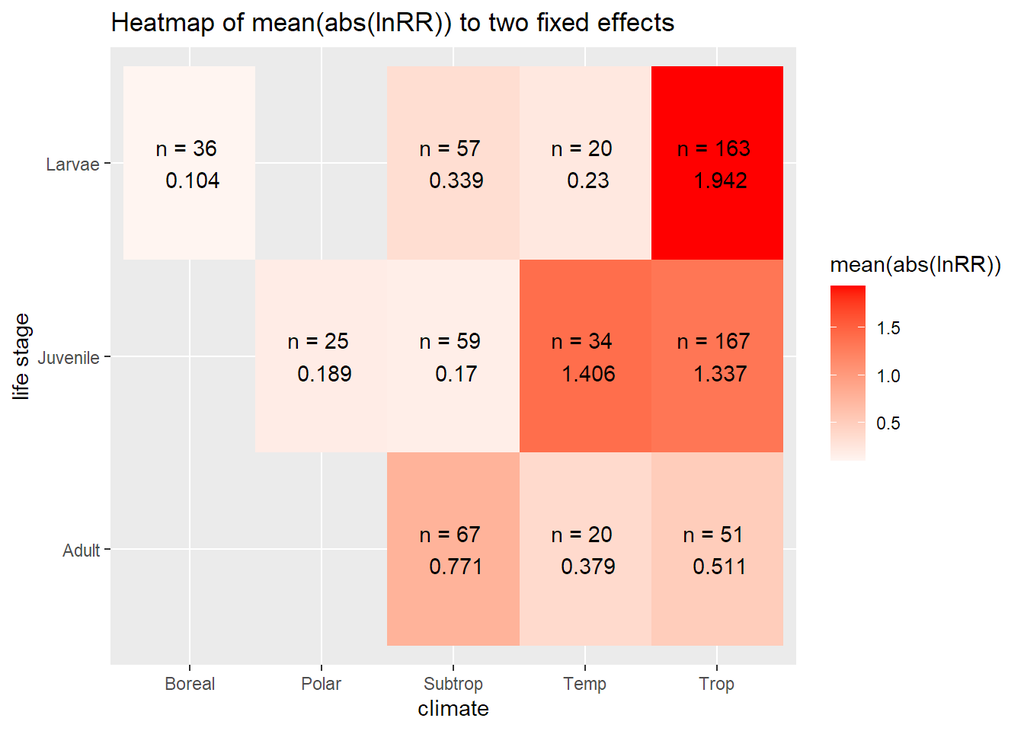

Figure 11: Heatmap of mean(abs(lnRR)) to two fixed effects

```r
#Calculate the average lnRR and sample size grouped by habitat and life stage
heat_data <- meta_RR_cs %>% group_by(climate_fish_base, life_stage) %>%
    summarise(mean_abs_lnRR = mean(abs_lnRR), n_sam = n(), .groups = "drop") %>% filter(n_sam > 10) %>%
    mutate(heat_label = paste("n =",n_sam,"\n",round(mean_abs_lnRR,3)))

heat_data %>% ggplot(aes(x= climate_fish_base ,y= life_stage,fill= mean_abs_lnRR, label = heat_label)) + geom_tile() + geom_text() + scale_fill_gradient2(low = "white", high = "red") + xlab("climate") + ylab("life stage") + labs(fill = "mean(abs(lnRR))") + ggtitle("Heatmap of mean(abs(lnRR)) to two fixed effects")
```

Fig 11 confirms that the magnitude of the absolute effect size varies significantly between the climate and life stages, and also shows that blocks with larger absolute effect sizes have larger sample sizes.

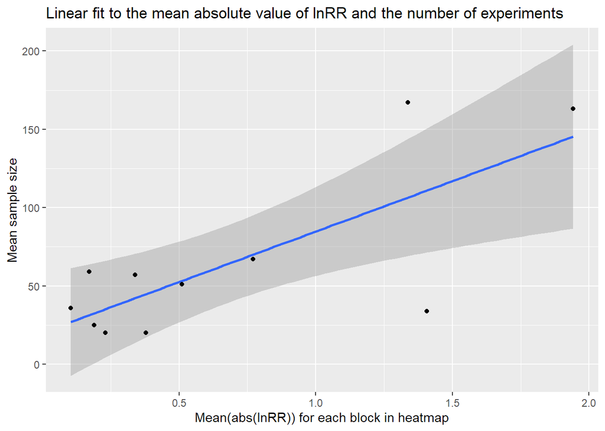

Figure 12: Linear fit to the mean absolute value of lnRR and the number of experiments

```r
heat_data %>% ggplot(aes(x = mean_abs_lnRR, y = n_sam)) + geom_smooth(method = "lm") + geom_point() + xlab("Mean(abs(lnRR)) for each block in heatmap") + ylab("Mean sample size") + ggtitle("Linear fit to the mean absolute value of lnRR and the number of experiments")
```

Fig 12 reveals that there is a strong positive correlation between the absolute value of the effect size and the number of studies for different “research fields”. It can be argued that **researchers prefer to conduct research in areas where it is easy to find significant effects**.

Finally, we explore whether the sample size has an effect on the size of the effect size, that is, the relationship between sample size and $|lnRR|$.

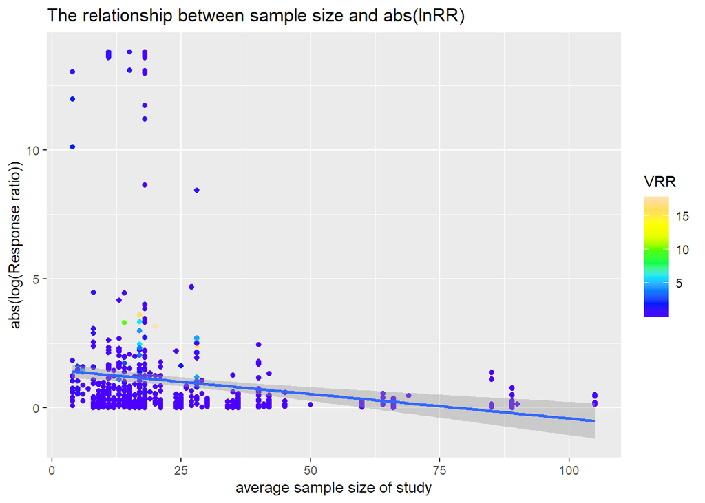

Figure 13: The relationship between sample size and abs(lnRR)

```r
meta_RR %>% filter(average_n < quantile(meta_RR$average_n,0.99)) %>% ggplot(aes(x = average_n, y = abs_lnRR, color = VRR)) + geom_point() + geom_smooth(method = lm) + scale_color_gradientn(colours = topo.colors(10)) + ggtitle("The relationship between sample size and abs(lnRR)") + ylab("abs(log(Response ratio))") + xlab("average sample size of study")
```

From Fig 13, it can be clearly seen that regions with low sample sizes tend to have higher absolute values of effect sizes, and also generally have larger sampling variances. Therefore, it can be seen that a **low sample size will lead to a greater possibility of bias** in the results of the experiment, and the reliability is often low.

### 6. Analysis of publication practices factor

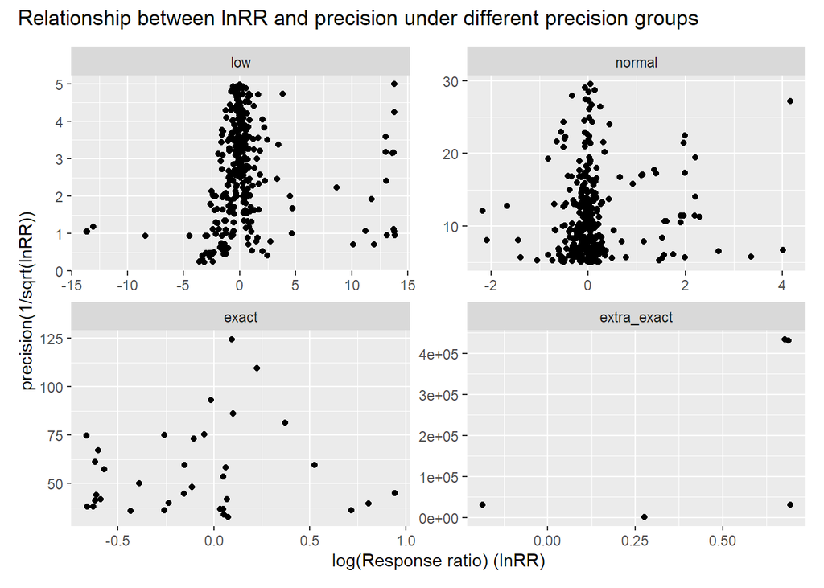

Figure 14: Relationship between lnRR and precision under different precision groups

```r
# use case_when() to divide samples into groups
meta_RR <- meta_RR %>% mutate(precision = 1/sqrt(VRR)) %>%  mutate(
    exact = case_when(
        precision < 5 ~ "low",
        precision >= 5 & precision < 30 ~ "normal",
        precision >= 30 & precision < 500 ~ "exact",
        precision >= 500 ~ "extra_exact",
  )) %>% mutate(exact = fct_relevel(as.factor(exact),"low","normal","exact"))
meta_RR %>% ggplot(aes(y = precision, x = lnRR)) + geom_point() + facet_wrap(~exact, scale = "free") + plot_annotation(
  title = "Relationship between lnRR and precision under different precision groups") + xlab("log(Response ratio) (lnRR)") + ylab("precision(1/sqrt(lnRR))")
```

We calculate the proportion of the sample size in each group to the population.

```r
precision_num <- meta_RR %>% count(across(exact)) %>% mutate(ratio = round(n/nrow(meta_RR),3))
knitr::kable(precision_num,caption = "The number and proportion of samples with different precision levels")
```

Table 4: The number and proportion of samples with different precision levels

| exact | n | ratio |
| --- | --- | --- |
| low | 333 | 0.458 |
| normal | 353 | 0.486 |
| exact | 36 | 0.050 |
| extra_exact | 5 | 0.007 |

Publication bias of study was examined by plotting funnel plots.

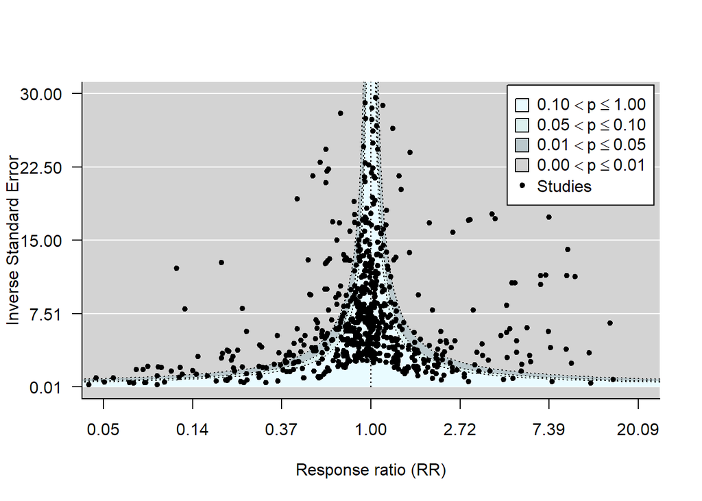

Figure 15: Funnel plot of lnRR and study precision

```r
metafor::funnel(x = meta_RR$lnRR, vi = meta_RR$VRR, yaxis = "seinv",
    digits = 2, level = c(0.1, 0.05, 0.01), shade = c("#e9fbff", "#dcf0ef", "#bac8cc"),ylim = c(0.01,30),xlim = c(-3,3),
    las = 1, xlab = "Response ratio (RR)", atransf = exp, legend = TRUE, pch =20)
```

We found no publication bias in the areas where the studies had higher precision. However, we found gaps at the bottom of the funnel plot Fig 15, implying that **studies with lower precision tended to be biased toward publishing results with more pronounced effects**, that is, results with larger absolute values of effect sizes.

To this end, we plot a linear fit of the sampling variance to the absolute value of $lnRR$ to examine the relationship between the absolute value of the effect size and the sampling variance/study precision.

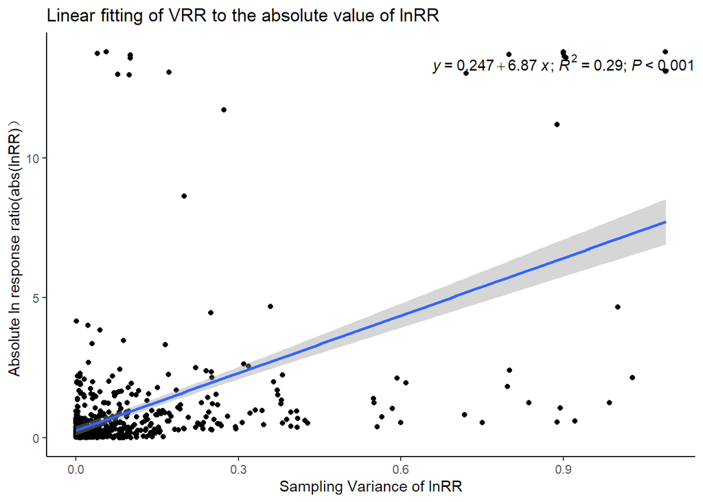

Figure 16: Linear fitting of VRR to the absolute value of lnRR

```r
library(ggpmisc)
anti_funnel <- function(data, diff_color){
    ggplot(data, aes(y = abs_lnRR, x = VRR, color = {{diff_color}})) + geom_point() + geom_smooth(method = lm, formula = y~x) +
    labs(y = "Absolute ln response ratio(abs(lnRR)）", x = "Sampling Variance of lnRR") +
    stat_poly_eq(use_label(c("eq","R2", "P"), sep = "*\"; \"*"),
    formula = y~x , label.x = 8, parse = TRUE) +
    theme_classic() + ggtitle("Linear fitting of VRR to the absolute value of lnRR")
}
# NULL means not to apply different colors to the two measurements of the data
meta_RR %>% filter(VRR < quantile(meta_RR$VRR,0.95)) %>% anti_funnel(NULL)
```

A fit to the post-95% sampling variance can be found to show a strong positive correlation. This suggests that **studies with larger sampling variances tend to publish results with larger absolute values of effect sizes**.

At the same time, according to Fig 16, we believe that the effect size distribution of the two different data measures is different, and therefore we believe that their responses to VRR may also be different. Therefore, we fit the same data separately for the two types of data.

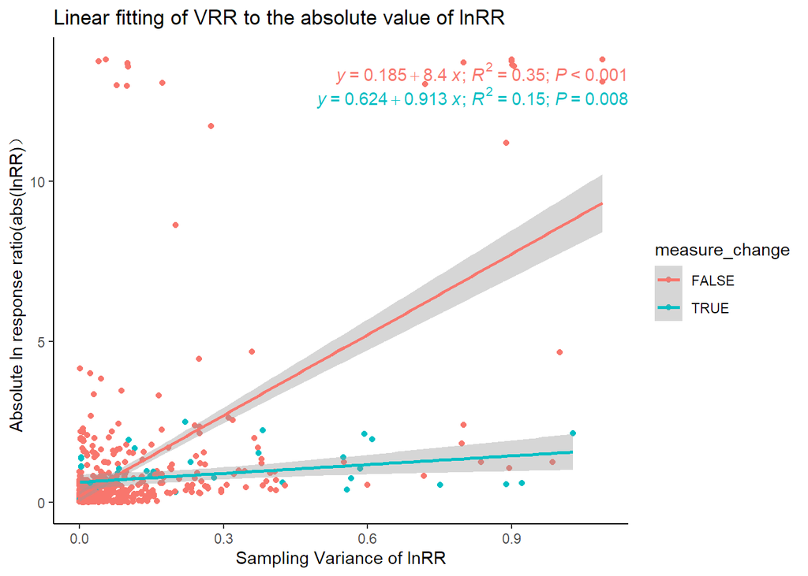

Figure 17: Linear fitting of VRR to the absolute value of lnRR to different measure type

```r
meta_RR %>% filter(VRR < quantile(meta_RR$VRR,0.95)) %>% anti_funnel(measure_change)
```

According to Fig 17, we obtain very interesting results. The study measuring the change quantity has a higher intercept of the absolute value of $lnRR$ , while the study measuring the non-change quantity has a smaller intercept of the absolute value of $lnRR$, yet has a higher slope. This is partly because the measurement of change itself leads to larger effect sizes, and partly because the measurement of such effect sizes leads to larger sampling variance, making the change in effect sizes less pronounced.

Meanwhile, we perform a meta-analysis of inverse sampling variance $1/V_{lnRR}$ versus $lnRR$. To filter too large values, we choose to refer to table 4 to take the 95% quantile.

```r
metareg_v <- metafor::rma.mv(lnRR ~ inverse_VRR, V = VRR, random = list(~1 | study/exp_id),
    test = "t", dfs = "contain", data = meta_RR %>% mutate(inverse_VRR = 1/VRR) %>% filter(inverse_VRR <= quantile(inverse_VRR, 0.95)))
metareg_v
```

```
##
## Multivariate Meta-Analysis Model (k = 690; method: REML)
##
## Variance Components:
##
##             estim    sqrt  nlvls  fixed        factor
## sigma^2.1  0.7008  0.8372     89     no         study
## sigma^2.2  4.4292  2.1046    690     no  study/exp_id
##
## Test for Residual Heterogeneity:
## QE(df = 688) = 56439.6399, p-val < .0001
##
## Test of Moderators (coefficient 2):
## F(df1 = 1, df2 = 688) = 5.4405, p-val = 0.0200
##
## Model Results:
##
##              estimate      se     tval   df    pval    ci.lb    ci.ub
## intrcpt        0.2727  0.1436   1.8987   87  0.0609  -0.0128   0.5582  .
## inverse_VRR   -0.0013  0.0006  -2.3325  688  0.0200  -0.0024  -0.0002  *
##
## ---
## Signif. codes:  0 '***' 0.001 '**' 0.01 '*' 0.05 '.' 0.1 ' ' 1
```

Next we look at the time-lag bias in ocean acidification studies.

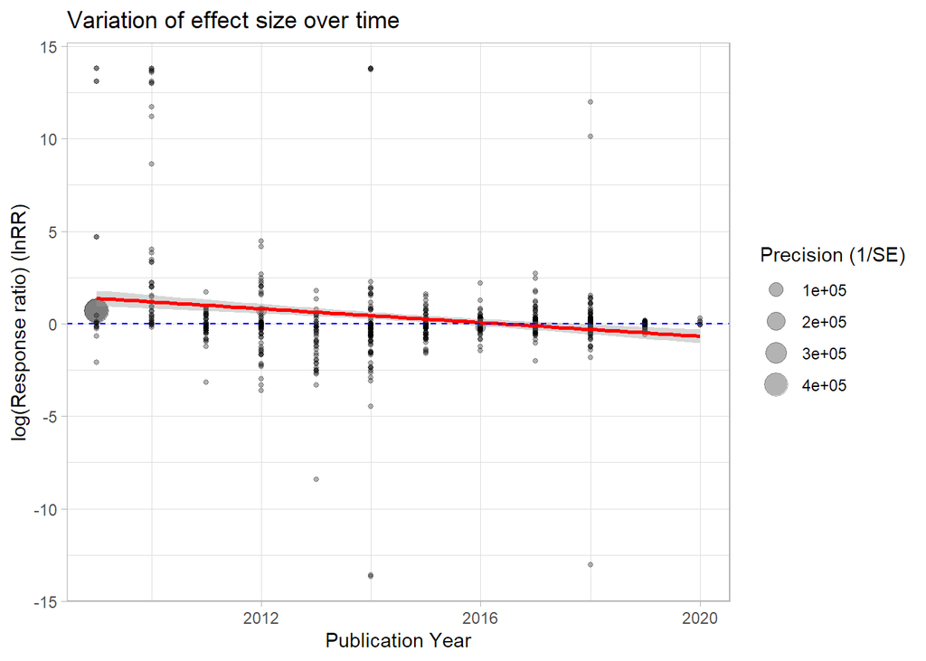

Figure 18: Variation of effect size over time

```r
ggplot(meta_RR, aes(y = lnRR, x = year_online, size = 1/sqrt(VRR))) + geom_point(alpha = 0.3) +
    geom_smooth(method = lm, col = "red", show.legend = FALSE) + labs(x = "Publication Year",
    y = "log(Response ratio) (lnRR)", size = "Precision (1/SE)") +
    geom_hline(yintercept = 0,col = "blue", linetype = 2)+
    theme_light() + ggtitle("Variation of effect size over time")
```

It can be clearly seen from Fig 18 that the mean value of the **effect size gradually decreases with the publication year** **and gradually converges to close to zero**.This shows that with the deepening of research, the effect of ocean acidification is gradually revised and reduced.

We can use the absolute value of the effect size to better observe the convergence of this effect size.

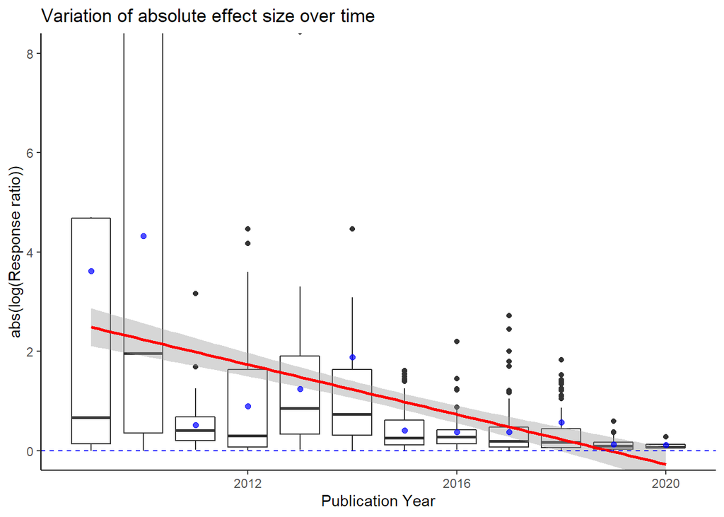

Figure 19: Variation of absolute effect size over time

```r
ggplot(meta_RR, aes(y = abs_lnRR, x = year_online, size = 1/sqrt(VRR))) + geom_boxplot(aes(group = year_online)) +
    geom_smooth(method = lm, col = "red", show.legend = FALSE) + labs(x = "Publication Year",
    y = "abs(log(Response ratio))", size = "Precision (1/SE)") +
    geom_hline(yintercept = 0,col = "blue", linetype = 2)+ coord_cartesian(ylim = c(0, 8))+
    stat_summary(fun="mean", geom="point", shape=20, size=2.5, color="blue", fill="blue",alpha=0.7) +
    theme_classic() + ggtitle("Variation of absolute effect size over time")
```

With the help of the box plot in Fig 19, we found that the absolute value of the effect size decreased in a wavy shape with the year. In 2020, the effect sizes obtained by basically all studies were around 0.

Therefore, we can build a meta-analysis model with time as a fixed factor.

```r
meta_RR <- meta_RR %>% mutate(year_c = year_online - mean(year_online))
metareg_time <- metafor::rma.mv(lnRR ~ year_c, V = VRR, random = list(~1 | study/exp_id),
    test = "t", dfs = "contain", data = meta_RR)
metareg_time
```

```
##
## Multivariate Meta-Analysis Model (k = 727; method: REML)
##
## Variance Components:
##
##             estim    sqrt  nlvls  fixed        factor
## sigma^2.1  0.4918  0.7012     92     no         study
## sigma^2.2  4.2465  2.0607    727     no  study/exp_id
##
## Test for Residual Heterogeneity:
## QE(df = 725) = 128790476.8445, p-val < .0001
##
## Test of Moderators (coefficient 2):
## F(df1 = 1, df2 = 90) = 6.9193, p-val = 0.0100
##
## Model Results:
##
##          estimate      se     tval  df    pval    ci.lb    ci.ub
## intrcpt    0.1447  0.1177   1.2290  90  0.2223  -0.0892   0.3786
## year_c    -0.1154  0.0439  -2.6305  90  0.0100  -0.2026  -0.0282  *
##
## ---
## Signif. codes:  0 '***' 0.001 '**' 0.01 '*' 0.05 '.' 0.1 ' ' 1
```

The results show a clear effect of year change on the effect size with a slope of -0.115 and a 95% confidence interval of -0.203 to -0.028. This means that the mean of the effect size decreases on average by -0.115 per year. Also the average effect value after removing the year effect is still 0.1447 greater than 0.

Finally, we combined time and study precision simultaneously as fixed effects for meta-analysis.To filter too large values, we choose to refer to table 4 to take the 99% quantile.

```r
metareg_publish <- metafor::rma.mv(lnRR ~ year_c + precision, V = VRR, random = list(~1 | study/exp_id),
    test = "t", dfs = "contain", data = meta_RR %>% filter(precision < quantile(meta_RR$precision,0.99)))
metareg_publish
```

```
##
## Multivariate Meta-Analysis Model (k = 719; method: REML)
##
## Variance Components:
##
##             estim    sqrt  nlvls  fixed        factor
## sigma^2.1  0.5639  0.7509     92     no         study
## sigma^2.2  4.2192  2.0541    719     no  study/exp_id
##
## Test for Residual Heterogeneity:
## QE(df = 716) = 71943.1278, p-val < .0001
##
## Test of Moderators (coefficients 2:3):
## F(df1 = 2, df2 = 89) = 7.3804, p-val = 0.0011
##
## Model Results:
##
##            estimate      se     tval   df    pval    ci.lb    ci.ub
## intrcpt      0.3646  0.1444   2.5245   89  0.0134   0.0776   0.6516   *
## year_c      -0.1244  0.0458  -2.7183   89  0.0079  -0.2153  -0.0335  **
## precision   -0.0220  0.0078  -2.8225  716  0.0049  -0.0373  -0.0067  **
##
## ---
## Signif. codes:  0 '***' 0.001 '**' 0.01 '*' 0.05 '.' 0.1 ' ' 1
```

The results show that both fixed effects are highly significant. where the slope of year is -0.124 (95% CI [-0.215,-0.033]), the slope of the precision is -0.022 (95% CI [-0.037, -0.007]). And the mean of the effect size obtained by removing the two fixed effects is 0.365 (95% CI [0.078,0.652]). We believe that the decay in effect values over time is due to **initial studies that exaggerated the effect of the study**, leading to an academic consensus that ocean acidification has a strong effect on species, while a growing number of subsequent experiments have gradually refuted the previously exaggerated effect sizes.

```r
R22 <- as.data.frame(orchaRd::r2_ml(metareg_v))
R22 <- cbind(R22,as.data.frame(orchaRd::r2_ml(metareg_time)))
R22 <- cbind(R22,as.data.frame(orchaRd::r2_ml(metareg_publish)))
colnames(R22) <- c("precision","year","year+precision")
knitr::kable(R22, caption = "Variance explained by different publication bias meta-analysis models")
```

Table 5: Variance explained by different publication bias meta-analysis models

|  | precision | year | year+precision |
| --- | --- | --- | --- |
| R2_marginal | 0.0092409 | 0.0221753 | 0.0374673 |
| R2_conditional | 0.1445907 | 0.1236574 | 0.1509424 |

As can be seen from the table 5, using both time and precision **better explains** the variance between experiments. The two fixed effects explained 3.7467331% of the variance, and were more powerful than biological effects.

Lastly, we investigated whether the impact factor influenced the publication of the study.

```r
study_info <- meta_RR %>% group_by(study) %>% mutate(mean_VRR = mean(VRR), species_usage = length(unique(species)), mean_lnRR = mean(lnRR), method_usage = length(unique(cue_stimulus_type))) %>% ungroup() %>%  select(study,year_online, pub_year_if,mean_VRR, effect_type, average_n, species_usage, method_usage,mean_lnRR) %>% distinct()
study_info <- study_info %>% mutate(if_range = c("0-20%","20-40%","40-60%","60-80%","80-100%")[findInterval(study_info$pub_year_if,c(0,quantile(study_info$pub_year_if,0.2,T),quantile(meta_RR$pub_year_if,0.4,T),quantile(study_info$pub_year_if,0.6,T),quantile(study_info$pub_year_if,0.8,T),100),all.inside = T)] )
```

First, we observed whether effect_type affected the impact factor of the study.

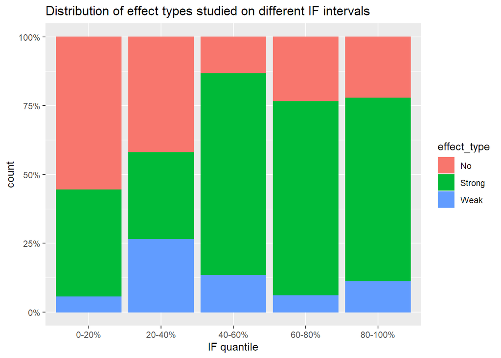

Figure 20: Distribution of effect types studied on different IF intervals

```r
study_info %>% drop_na() %>%
ggplot(aes(x= if_range,fill=effect_type)) + geom_bar(aes(color=effect_type), position = "fill")+scale_y_continuous(labels = scales::percent) + ggtitle("Distribution of effect types studied on different IF intervals") + xlab("IF quantile")
```

From Fig 20 it can be seen that the majority of studies with no effect were published in journals with low impact factor quartiles, while the majority of studies with strong effects were published in journals with high impact factor quartiles, which seems to **indicate the acceptance bias of the journals**.

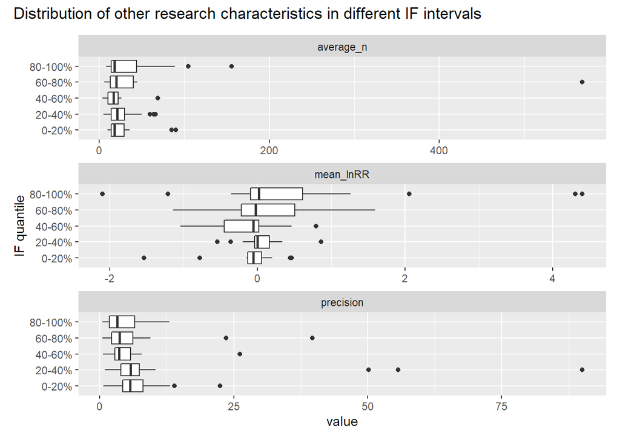

Figure 21: Distribution of other research characteristics in different IF intervals

```r
study_info %>% drop_na() %>% mutate(precision = 1/sqrt(mean_VRR)) %>% pivot_longer(c(mean_lnRR,average_n,precision),names_to = "trait", values_to = "value") %>%
ggplot(aes(y= if_range,x = value)) + geom_boxplot() + facet_wrap(~trait,scale = "free",nrow = 3) +  plot_annotation(
  title = "Distribution of other research characteristics in different IF intervals") + ylab("IF quantile")
```

In the analysis of Fig 21 impact factors in other study characteristics, we found that the precision of the studies did not change significantly as the quantile of impact factors rose, while the range of variation in effect size increased overall and the sample size of the studies increased. This seems to imply that **articles with high impact factors do not require as much precision as they do sample size**.

Finally, we examine whether the number of species and methods used in published studies increases as the impact factor increases.

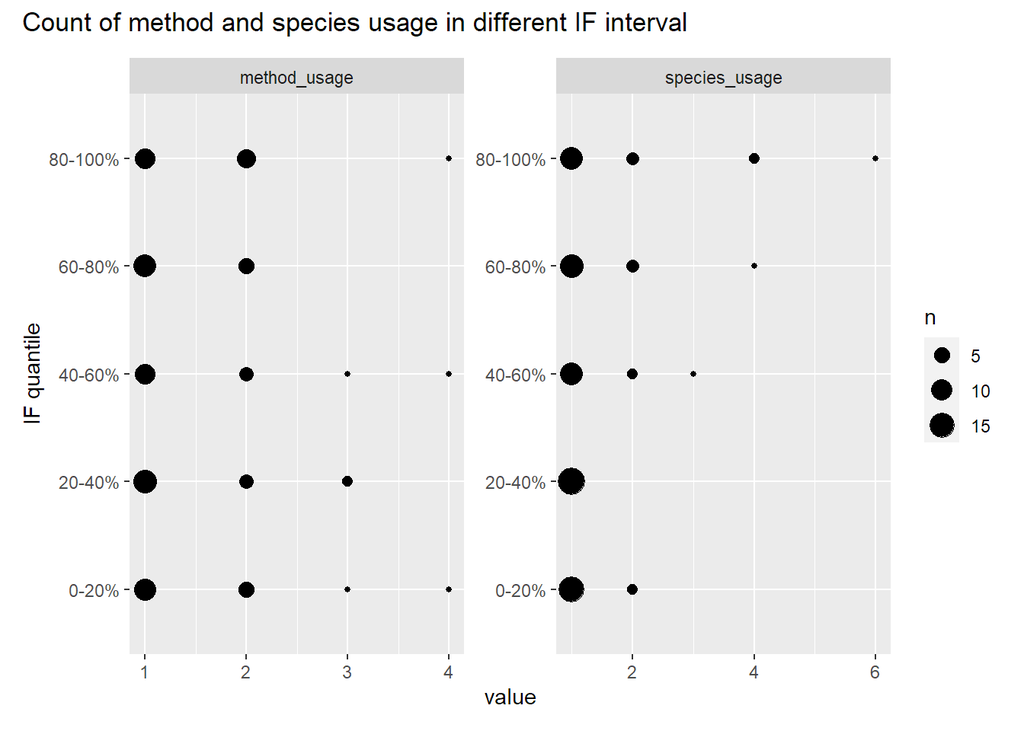

Figure 22: Count of method and species usage in different IF interval

```r
study_info %>% drop_na() %>% pivot_longer(c(species_usage,method_usage),names_to = "trait", values_to = "value") %>% ggplot(aes(y= if_range,x = value)) + geom_count() + facet_wrap(~trait,scale = "free",ncol = 2) +  plot_annotation(
  title = "Count of method and species usage in different IF interval") + ylab("IF quantile")
```

Fig 22 shows that the **number of methods used in the study did not increase with increasing impact factors**, while the number of species used increased overall.

A more pronounced effect of different publication factors on the absolute value of the effect size was found from Fig 17, Fig 19 and Fig 22. To represent the effect of different publication bias manifold on the absolute value of effect size, we fit a meta-analytic model to the absolute value of $lnRR$.

```r
metareg_all <- metafor::rma.mv(abs_lnRR ~ year_c + pub_year_if + precision , V = VRR, random = list(~1 | study/exp_id),
    test = "t", dfs = "contain", data = meta_RR)
metareg_all
```

```
##
## Multivariate Meta-Analysis Model (k = 705; method: REML)
##
## Variance Components:
##
##             estim    sqrt  nlvls  fixed        factor
## sigma^2.1  0.5089  0.7134     87     no         study
## sigma^2.2  3.5112  1.8738    705     no  study/exp_id
##
## Test for Residual Heterogeneity:
## QE(df = 701) = 179290.6662, p-val < .0001
##
## Test of Moderators (coefficients 2:4):
## F(df1 = 3, df2 = 83) = 6.7124, p-val = 0.0004
##
## Model Results:
##
##              estimate      se     tval   df    pval    ci.lb    ci.ub
## intrcpt        0.6106  0.1434   4.2591   83  <.0001   0.3255   0.8958  ***
## year_c        -0.1720  0.0434  -3.9641   83  0.0002  -0.2583  -0.0857  ***
## pub_year_if    0.0209  0.0141   1.4766   83  0.1436  -0.0072   0.0490
## precision     -0.0000  0.0000  -2.0514  701  0.0406  -0.0000  -0.0000    *
##
## ---
## Signif. codes:  0 '***' 0.001 '**' 0.01 '*' 0.05 '.' 0.1 ' ' 1
```

### 7. Conclusion

In conjunction with Clement et. al. (2022) and others, we suggest that researchers and journal publishers should try to avoid publication bias and focus more on experimental accuracy, scope, and richness of experimental tools, and should maintain transparency, data availability, and reproducibility of published studies. Researchers should always think critically in the face of early exaggerated effects, and should not just blindly replicate the conditions of previous studies, but should pay attention to whether the effect is generalizable.